# Peer-graded Assignment: Reproducible Research Project 1

TSA

4/19/2019

## Introduction

This assignment makes use of data from a personal activity monitoring device. This device collects data at 5 minute intervals through out the day. The data consists of two months of data from an anonymous individual collected during the months of October and November, 2012 and include the number of steps taken in 5 minute intervals each day.

The data for this assignment can be downloaded from the course web site:

**Dataset**: Activity monitoring data [52K] The variables included in this dataset are:

-**steps**: Number of steps taking in a 5-minute interval (missing values are coded as **NA**)  
-**date**: The date on which the measurement was taken in YYYY-MM-DD format.  
-**interval**: Identifier for the 5-minute interval in which measurement was taken.  
The [dataset](https://d396qusza40orc.cloudfront.net/repdata%2Fdata%2Factivity.zip) is stored in ‘activity.csv’, a comma-separated-value (CSV) file and there are a total of 17,568 observations in this dataset.

## Overview

The components of this project are:  
1. Loading and preprocessing the data  
2. What is mean total number of steps taken per day?  
3. What is the average daily activity pattern?  
4. Imputing missing values  
5. Are there differences in activity patterns between weekdays and weekends?

Results 1.Code for reading in the dataset and/or processing the data  
2.Histogram of the total number of steps taken each day  
3.Mean and median number of steps taken each day  
4.Time series plot of the average number of steps taken  
5.The 5-minute interval that, on average, contains the maximum number of steps  
6.Code to describe and show a strategy for imputing missing data  
7.Histogram of the total number of steps taken each day after missing values are imputed  
8.Panel plot comparing the average number of steps taken per 5-minute interval across weekdays and weekends

## 1. Loading and preprocessing the data

1. Code for reading in the dataset and/or processing the data

```r
# Create data directory if it does not exists
#
       if(!file.exists('./data')) dir.create('./data')
#
```

Get data if needed.

```r
#
       if(!file.exists('./data/activity_data.zip')) {
          fileURL <- 'https://d396qusza40orc.cloudfront.net/repdata%2Fdata%2Factivity.zip'
          download.file(fileURL, destfile = './data/activity_data.zip')
       }
# Unzip data if needed
#
       if(!file.exists('./data/activity.csv')) {
          unzip('./data/activity_data.zip', exdir = './data')
        }
#
#
        fileName = "./data/activity.csv"
# Read data
        data <- read.csv(fileName,sep=",", header = TRUE,
                         colClasses = c("numeric","Date","numeric"), na.strings ="NA")

        summary (data)
```

```
##      steps             date               interval
##  Min.   :  0.00   Min.   :2012-10-01   Min.   :   0.0
##  1st Qu.:  0.00   1st Qu.:2012-10-16   1st Qu.: 588.8
##  Median :  0.00   Median :2012-10-31   Median :1177.5
##  Mean   : 37.38   Mean   :2012-10-31   Mean   :1177.5
##  3rd Qu.: 12.00   3rd Qu.:2012-11-15   3rd Qu.:1766.2
##  Max.   :806.00   Max.   :2012-11-30   Max.   :2355.0
##  NA's   :2304
```

## 2. What is mean total number of steps taken per day?

```r
       library(ggplot2)

# First sum according to date
       ans<-data %>%
              group_by(date) %>%
              summarise(steps = sum(steps))
       names(data)
```

[1] “steps” “date” “interval”

```r
       dim(data)
```

[1] 17568 3

```r
       summary(ans)
```

```
  date                steps
```

Min. :2012-10-01 Min. : 41  
1st Qu.:2012-10-16 1st Qu.: 8841  
Median :2012-10-31 Median :10765  
Mean :2012-10-31 Mean :10766  
3rd Qu.:2012-11-15 3rd Qu.:13294  
Max. :2012-11-30 Max. :21194  
NA’s :8

```r
# Imputation of the data when calculating the mean and median
       mean.result1 <- median(ans$steps,na.rm = TRUE)
       mean.result1
```

```
## [1] 10765
```

```r
       median.result1 <- median(ans$steps,na.rm = TRUE)
       median.result1
```

```
## [1] 10765
```

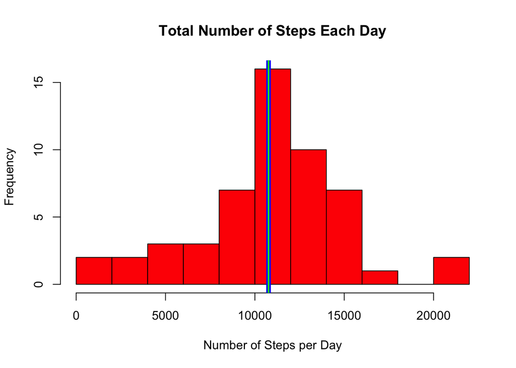

```r
       hist(ans$steps,col="red", xlab="Number of Steps per Day", breaks=10,
            main = "Total Number of Steps Each Day")
       abline(v = c(mean.result1,median.result1), col = c("blue","green"), lwd = c(6,2))
```

## 3. What is the average daily activity pattern?

The time series plot of the average number of steps taken is executed with the *plot* function.

```r
# Imputation of the data when calculating mean per interval
       ans2<-aggregate(x=data$steps, by=list(interval=data$interval),
                       FUN=mean,na.rm = TRUE)
       dim(ans2)
```

```
## [1] 288   2
```

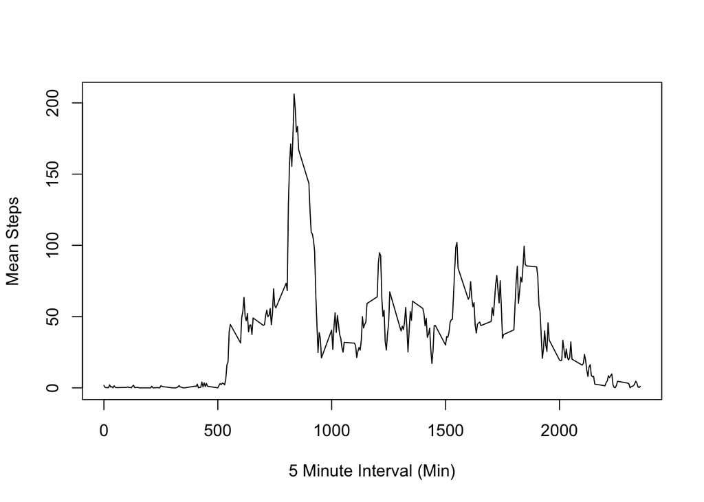

```r
       plot(ans2$interval,ans2$x,type="l", xlab="5 Minute Interval (Min)", ylab="Mean Steps")
```

```r
       summary(ans2)
```

```
##     interval            x
##  Min.   :   0.0   Min.   :  0.000
##  1st Qu.: 588.8   1st Qu.:  2.486
##  Median :1177.5   Median : 34.113
##  Mean   :1177.5   Mean   : 37.383
##  3rd Qu.:1766.2   3rd Qu.: 52.835
##  Max.   :2355.0   Max.   :206.170
```

```r
# The maximum average number of steps per interval
       max(ans2$x)
```

```
## [1] 206.1698
```

```r
# The position of the maximum number of steps
       maxPos <- which.max(ans2$x)
# Corresponding 5 minute interval for max steps occurs at maxPos
       ans2$interval[maxPos]
```

```
## [1] 835
```

## 4. Code to describe and show a strategy for imputing missing data

1. The total number of missing values in the dataset (i.e. the total number of rows with NAs) is calculated below. The answer for the entire table is compared against the steps column to verify that all missing data are accounted for in the steps column alone.

```r
       sum(is.na(data))
```

```
## [1] 2304
```

```r
# See that all missing data are attributed to STEPS
       sum(is.na(data$steps))
```

```
## [1] 2304
```

2. The strategy for filling in all of the missing values in the dataset is to use mean 5-minute interval for the NAs.
3. A new dataset (data2) is created below that is equal to the original dataset but with the missing data filled in.

```r
       data2<-data

# From inspection of data, a day has 288 intervals (nrows of ans2)
# Loop on days to assign 5-min interval mean to 5-min interval NA.
       jlim <- nrow(data2)/nrow(ans2)
       for (j in 1:jlim){
              for(i in 1:nrow(ans2)) {
                     k<-(j-1)*nrow(ans2)+i
                     data2$steps[k][is.na(data2$steps[k])] <-ans2$x[i]
              }
       }
```

4. A histogram of the total number of steps taken each day is plotted here. The mean and median total number of steps taken per day are calculated and shown. These values do not differ much from the estimates from the first part of the assignment. The impact of imputing missing data with the means has very little impact on the estimates of the total daily number of steps.

```r
# First sum according to date
       newAns<-data2 %>%
              group_by(date) %>%
              summarise(steps = sum(steps))
# Summary function displays the mean and median...
       summary(newAns)
```

```
  date                steps
```

Min. :2012-10-01 Min. : 41  
1st Qu.:2012-10-16 1st Qu.: 9819  
Median :2012-10-31 Median :10766  
Mean :2012-10-31 Mean :10766  
3rd Qu.:2012-11-15 3rd Qu.:12811  
Max. :2012-11-30 Max. :21194

```r
# Calculate the mean and median of new mean of newAns
       mean.result2 <- median(newAns$steps,na.rm = FALSE)
       mean.result2
```

[1] 10766.19

```r
       median.result2 <- median(newAns$steps,na.rm = FALSE)
       median.result2
```

[1] 10766.19

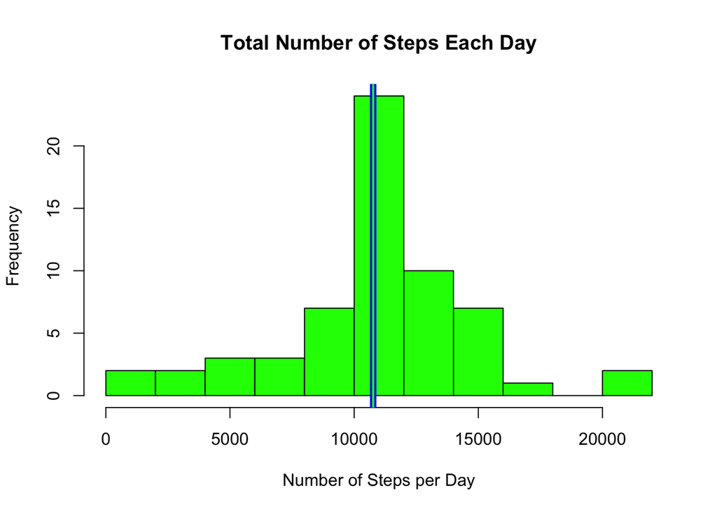

```r
       hist(newAns$steps,col="green", xlab="Number of Steps per Day", breaks=10,
            main = "Total Number of Steps Each Day")
       abline(v = c(mean.result2,median.result2), col = c("blue","green"), lwd = c(6,2))
```

It is not surprising that imputing the data with the mean does not change the mean or median, as seen above. Imputing the data does make the histogram have greater max and steepens the shape of the envelope.

## 5. Are there differences in activity patterns between weekdays and weekends?

A new factor variable “day” is created in the dataset with two levels – “weekday” and “weekend” indicating whether a given date is a weekday or weekend day. First all days are assigned value “weekday”. Then the *weekdays* function is used to check for Sundays and Saturdays and assign those days as “weekends”.

```r
# First add day to data2 and assign all day to weekdays
       data2$day<-"weekday"
#
       for (i in 1: nrow(data2)){
              if(weekdays(data2$date[i], abbreviate = FALSE) == "Sunday"|
                 weekdays(data2$date[i], abbreviate = FALSE) == "Saturday"){
                      data2$day[i]<- "weekend"
              }
       }
```

-Make a panel plot containing a time series plot (i.e.type=“l”) of the 5-minute interval (x-axis) and the average number of steps taken, averaged across all weekday days or weekend days (y-axis). See the README file in the GitHub repository to see an example of what this plot should look like using simulated data.

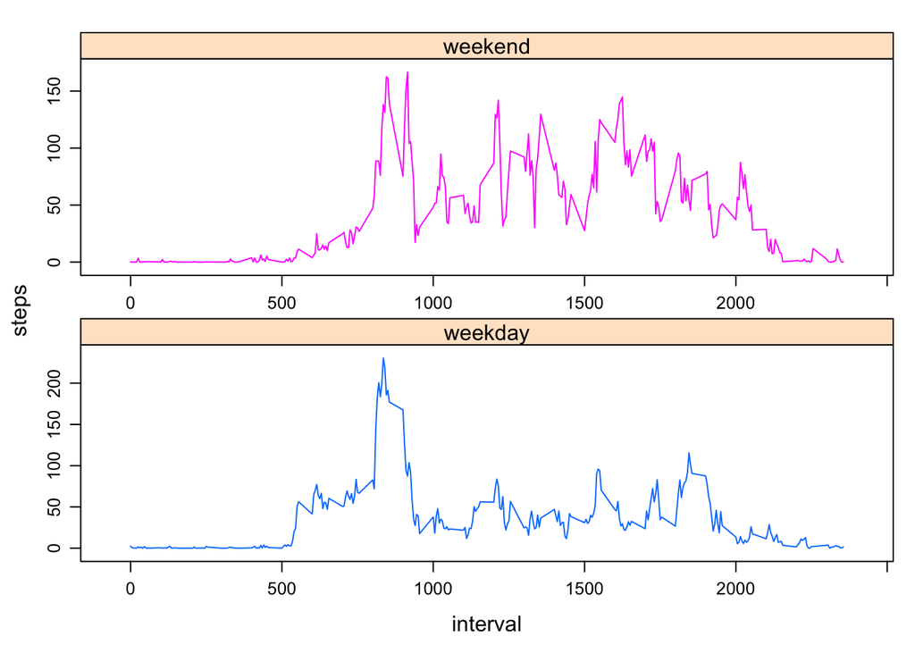

```r
# First sum according to date

       WkDays<-data2 %>%
               filter(day == "weekday")%>%
               group_by(interval) %>%
               summarise(steps = mean(steps))
       WkDays$day<-"weekday"
       EndDays<-data2 %>%
               filter(day == "weekend")%>%
               group_by(interval) %>%
               summarise(steps = mean(steps))
       EndDays$day<-"weekend"
# Row bind the answers into one table for use with lattice plotting.
       xx<-rbind(WkDays,EndDays)

         xyplot(steps ~ interval | day,
              group = day, data = xx,
              type = c("l"),
              scales = "free", layout=c(1,2) )
```